```python
import pandas as pd
import numpy as np
import seaborn as sns
from datetime import datetime
import matplotlib.pyplot as plt

# Shows plots in jupyter notebook
%matplotlib inline

# Set plot style
sns.set(color_codes=True)
```

```python
client_df = pd.read_csv('C:/Users/Tasnim/Desktop/dataUsed2/client_data.csv')
price_df = pd.read_csv('C:/Users/Tasnim/Desktop/dataUsed2//price_data.csv')
```

```python
client_df.head(3)
```

|  | id | channel_sales | cons_12m | cons_gas_12m | cons_last_month | date_activ | date_end | date_modif_prod | date_renewal | forecast_cons_12m | ... | has_gas | imp_cons | margin_gross_pow_ele | margin_net_pow_ele | nb_prod_act | net_margin | num_years_antig | origin_up | pow_max | churn |
| --- | --- | --- | --- | --- | --- | --- | --- | --- | --- | --- | --- | --- | --- | --- | --- | --- | --- | --- | --- | --- | --- |
| 0 | 24011ae4ebbe3035111d65fa7c15bc57 | foosdfpfkusacimwkcsosbicdxkicaua | 0 | 54946 | 0 | 2013-06-15 | 2016-06-15 | 2015-11-01 | 2015-06-23 | 0.00 | ... | t | 0.0 | 25.44 | 25.44 | 2 | 678.99 | 3 | lxidpiddsbxsbosboudacockeimpuepw | 43.648 | 1 |
| 1 | d29c2c54acc38ff3c0614d0a653813dd | MISSING | 4660 | 0 | 0 | 2009-08-21 | 2016-08-30 | 2009-08-21 | 2015-08-31 | 189.95 | ... | f | 0.0 | 16.38 | 16.38 | 1 | 18.89 | 6 | kamkkxfxxuwbdslkwifmmcsiusiuosws | 13.800 | 0 |
| 2 | 764c75f661154dac3a6c254cd082ea7d | foosdfpfkusacimwkcsosbicdxkicaua | 544 | 0 | 0 | 2010-04-16 | 2016-04-16 | 2010-04-16 | 2015-04-17 | 47.96 | ... | f | 0.0 | 28.60 | 28.60 | 1 | 6.60 | 6 | kamkkxfxxuwbdslkwifmmcsiusiuosws | 13.856 | 0 |

3 rows × 26 columns

```python
price_df.head(3)
```

|  | id | price_date | price_off_peak_var | price_peak_var | price_mid_peak_var | price_off_peak_fix | price_peak_fix | price_mid_peak_fix |
| --- | --- | --- | --- | --- | --- | --- | --- | --- |
| 0 | 038af19179925da21a25619c5a24b745 | 2015-01-01 | 0.151367 | 0.0 | 0.0 | 44.266931 | 0.0 | 0.0 |
| 1 | 038af19179925da21a25619c5a24b745 | 2015-02-01 | 0.151367 | 0.0 | 0.0 | 44.266931 | 0.0 | 0.0 |
| 2 | 038af19179925da21a25619c5a24b745 | 2015-03-01 | 0.151367 | 0.0 | 0.0 | 44.266931 | 0.0 | 0.0 |

```python
#Descriptive statistics of data
```

```python
client_df.info()
```

```
<class 'pandas.core.frame.DataFrame'>
RangeIndex: 14606 entries, 0 to 14605
Data columns (total 26 columns):
 #   Column                          Non-Null Count  Dtype
---  ------                          --------------  -----
 0   id                              14606 non-null  object
 1   channel_sales                   14606 non-null  object
 2   cons_12m                        14606 non-null  int64
 3   cons_gas_12m                    14606 non-null  int64
 4   cons_last_month                 14606 non-null  int64
 5   date_activ                      14606 non-null  object
 6   date_end                        14606 non-null  object
 7   date_modif_prod                 14606 non-null  object
 8   date_renewal                    14606 non-null  object
 9   forecast_cons_12m               14606 non-null  float64
```

[output cut: 18 more lines]

```python
missing_values = client_df.isna().sum()
```

```python
missing_values
```

```
id                                0
channel_sales                     0
cons_12m                          0
cons_gas_12m                      0
cons_last_month                   0
date_activ                        0
date_end                          0
date_modif_prod                   0
date_renewal                      0
forecast_cons_12m                 0
forecast_cons_year                0
forecast_discount_energy          0
forecast_meter_rent_12m           0
forecast_price_energy_off_peak    0
forecast_price_energy_peak        0
forecast_price_pow_off_peak       0
has_gas                           0
imp_cons                          0
margin_gross_pow_ele              0
margin_net_pow_ele                0
nb_prod_act                       0
net_margin                        0
num_years_antig                   0
origin_up                         0
pow_max                           0
churn                             0
dtype: int64
```

```python
# Count occurrences of 'MISSING' in a specific column
missing_count = (client_df['channel_sales'] == 'MISSING').sum()

# Alternatively, to count 'MISSING' in all columns:
missing_count_all_columns = (client_df == 'MISSING').sum().sum()
```

```python
missing_count
```

```
3725
```

```python
missing_count_all_columns
```

```
3789
```

```python
# Replace 'your_column' with the actual name of the column
column_name1 = 'channel_sales'
column_name2 = 'origin_up'

# Filter out rows where the specified column contains 'MISSING'
client_df = client_df[client_df[column_name1] != 'MISSING']
client_df = client_df[client_df[column_name2] != 'MISSING']

# Save the filtered dataset to a new file or overwrite the original file
# Save the filtered DataFrame to a new CSV file
client_df.to_csv('client_df2.csv', index=False)
```

```python
client_df
```

|  | id | channel_sales | cons_12m | cons_gas_12m | cons_last_month | date_activ | date_end | date_modif_prod | date_renewal | forecast_cons_12m | ... | has_gas | imp_cons | margin_gross_pow_ele | margin_net_pow_ele | nb_prod_act | net_margin | num_years_antig | origin_up | pow_max | churn |
| --- | --- | --- | --- | --- | --- | --- | --- | --- | --- | --- | --- | --- | --- | --- | --- | --- | --- | --- | --- | --- | --- |
| 0 | 24011ae4ebbe3035111d65fa7c15bc57 | foosdfpfkusacimwkcsosbicdxkicaua | 0 | 54946 | 0 | 2013-06-15 | 2016-06-15 | 2015-11-01 | 2015-06-23 | 0.00 | ... | t | 0.00 | 25.44 | 25.44 | 2 | 678.99 | 3 | lxidpiddsbxsbosboudacockeimpuepw | 43.648 | 1 |
| 2 | 764c75f661154dac3a6c254cd082ea7d | foosdfpfkusacimwkcsosbicdxkicaua | 544 | 0 | 0 | 2010-04-16 | 2016-04-16 | 2010-04-16 | 2015-04-17 | 47.96 | ... | f | 0.00 | 28.60 | 28.60 | 1 | 6.60 | 6 | kamkkxfxxuwbdslkwifmmcsiusiuosws | 13.856 | 0 |
| 3 | bba03439a292a1e166f80264c16191cb | lmkebamcaaclubfxadlmueccxoimlema | 1584 | 0 | 0 | 2010-03-30 | 2016-03-30 | 2010-03-30 | 2015-03-31 | 240.04 | ... | f | 0.00 | 30.22 | 30.22 | 1 | 25.46 | 6 | kamkkxfxxuwbdslkwifmmcsiusiuosws | 13.200 | 0 |
| 5 | 1aa498825382410b098937d65c4ec26d | usilxuppasemubllopkaafesmlibmsdf | 8302 | 0 | 1998 | 2011-12-09 | 2016-12-09 | 2015-11-01 | 2015-12-10 | 796.94 | ... | f | 181.21 | 33.12 | 33.12 | 1 | 118.89 | 4 | lxidpiddsbxsbosboudacockeimpuepw | 13.200 | 1 |
| 6 | 7ab4bf4878d8f7661dfc20e9b8e18011 | foosdfpfkusacimwkcsosbicdxkicaua | 45097 | 0 | 0 | 2011-12-02 | 2016-12-02 | 2011-12-02 | 2015-12-03 | 8069.28 | ... | f | 0.00 | 4.04 | 4.04 | 1 | 346.63 | 4 | lxidpiddsbxsbosboudacockeimpuepw | 15.000 | 1 |
| ... | ... | ... | ... | ... | ... | ... | ... | ... | ... | ... | ... | ... | ... | ... | ... | ... | ... | ... | ... | ... | ... |
| 14600 | c49217f16a06263e5381eaba94a67a8b | foosdfpfkusacimwkcsosbicdxkicaua | 87146 | 0 | 11367 | 2013-02-08 | 2016-02-08 | 2013-02-08 | 2015-02-09 | 712.33 | ... | f | 71.81 | 66.00 | 66.00 | 1 | 87.14 | 3 | lxidpiddsbxsbosboudacockeimpuepw | 26.400 | 0 |
| 14601 | 18463073fb097fc0ac5d3e040f356987 | foosdfpfkusacimwkcsosbicdxkicaua | 32270 | 47940 | 0 | 2012-05-24 | 2016-05-08 | 2015-05-08 | 2014-05-26 | 4648.01 | ... | t | 0.00 | 27.88 | 27.88 | 2 | 381.77 | 4 | lxidpiddsbxsbosboudacockeimpuepw | 15.000 | 0 |
| 14602 | d0a6f71671571ed83b2645d23af6de00 | foosdfpfkusacimwkcsosbicdxkicaua | 7223 | 0 | 181 | 2012-08-27 | 2016-08-27 | 2012-08-27 | 2015-08-28 | 631.69 | ... | f | 15.94 | 0.00 | 0.00 | 1 | 90.34 | 3 | lxidpiddsbxsbosboudacockeimpuepw | 6.000 | 1 |
| 14603 | 10e6828ddd62cbcf687cb74928c4c2d2 | foosdfpfkusacimwkcsosbicdxkicaua | 1844 | 0 | 179 | 2012-02-08 | 2016-02-07 | 2012-02-08 | 2015-02-09 | 190.39 | ... | f | 18.05 | 39.84 | 39.84 | 1 | 20.38 | 4 | lxidpiddsbxsbosboudacockeimpuepw | 15.935 | 1 |
| 14604 | 1cf20fd6206d7678d5bcafd28c53b4db | foosdfpfkusacimwkcsosbicdxkicaua | 131 | 0 | 0 | 2012-08-30 | 2016-08-30 | 2012-08-30 | 2015-08-31 | 19.34 | ... | f | 0.00 | 13.08 | 13.08 | 1 | 0.96 | 3 | lxidpiddsbxsbosboudacockeimpuepw | 11.000 | 0 |

10831 rows × 26 columns

```python
# Count occurrences of 'MISSING' in a specific column
missing_count = (client_df['channel_sales'] == 'MISSING').sum()

# Alternatively, to count 'MISSING' in all columns:
missing_count_all_columns = (client_df == 'MISSING').sum().sum()
```

```python
missing_count
```

```
0
```

```python
client_df.info()
```

```
<class 'pandas.core.frame.DataFrame'>
Index: 10831 entries, 0 to 14604
Data columns (total 26 columns):
 #   Column                          Non-Null Count  Dtype
---  ------                          --------------  -----
 0   id                              10831 non-null  object
 1   channel_sales                   10831 non-null  object
 2   cons_12m                        10831 non-null  int64
 3   cons_gas_12m                    10831 non-null  int64
 4   cons_last_month                 10831 non-null  int64
 5   date_activ                      10831 non-null  object
 6   date_end                        10831 non-null  object
 7   date_modif_prod                 10831 non-null  object
 8   date_renewal                    10831 non-null  object
 9   forecast_cons_12m               10831 non-null  float64
```

[output cut: 18 more lines]

```python
price_df.info()
```

```
<class 'pandas.core.frame.DataFrame'>
RangeIndex: 193002 entries, 0 to 193001
Data columns (total 8 columns):
 #   Column              Non-Null Count   Dtype
---  ------              --------------   -----
 0   id                  193002 non-null  object
 1   price_date          193002 non-null  object
 2   price_off_peak_var  193002 non-null  float64
 3   price_peak_var      193002 non-null  float64
 4   price_mid_peak_var  193002 non-null  float64
 5   price_off_peak_fix  193002 non-null  float64
 6   price_peak_fix      193002 non-null  float64
 7   price_mid_peak_fix  193002 non-null  float64
dtypes: float64(6), object(2)
memory usage: 11.8+ MB
```

```python
# Alternatively, to count 'MISSING' in all columns:
missing_count_all_columns = (price_df == 'MISSING').sum().sum()
```

```python
missing_count_all_columns
```

```
0
```

```python
client_df.describe()
```

|  | cons_12m | cons_gas_12m | cons_last_month | forecast_cons_12m | forecast_cons_year | forecast_discount_energy | forecast_meter_rent_12m | forecast_price_energy_off_peak | forecast_price_energy_peak | forecast_price_pow_off_peak | imp_cons | margin_gross_pow_ele | margin_net_pow_ele | nb_prod_act | net_margin | num_years_antig | pow_max | churn |
| --- | --- | --- | --- | --- | --- | --- | --- | --- | --- | --- | --- | --- | --- | --- | --- | --- | --- | --- |
| count | 1.083100e+04 | 1.083100e+04 | 10831.000000 | 10831.000000 | 10831.000000 | 10831.000000 | 10831.000000 | 10831.000000 | 10831.000000 | 10831.000000 | 10831.000000 | 10831.000000 | 10831.000000 | 10831.000000 | 10831.000000 | 10831.000000 | 10831.000000 | 10831.000000 |
| mean | 1.752256e+05 | 2.846208e+04 | 17506.815345 | 1910.533724 | 1392.074416 | 1.073031 | 62.870387 | 0.138372 | 0.049933 | 43.217286 | 154.814143 | 25.309231 | 25.305720 | 1.277352 | 195.353669 | 4.487490 | 18.001682 | 0.104515 |
| std | 6.129525e+05 | 1.702019e+05 | 68178.552846 | 2377.560705 | 2859.244575 | 5.350617 | 65.569271 | 0.022869 | 0.049370 | 2.941194 | 317.884212 | 21.025921 | 21.024888 | 0.681292 | 340.347293 | 1.170981 | 12.829748 | 0.305941 |
| min | 0.000000e+00 | 0.000000e+00 | 0.000000 | 0.000000 | 0.000000 | 0.000000 | 0.000000 | 0.000000 | 0.000000 | 0.000000 | 0.000000 | 0.000000 | 0.000000 | 1.000000 | 0.000000 | 1.000000 | 3.300000 | 0.000000 |
| 25% | 5.893000e+03 | 0.000000e+00 | 0.000000 | 519.435000 | 0.000000 | 0.000000 | 16.190000 | 0.116509 | 0.000000 | 40.606701 | 0.000000 | 14.640000 | 14.640000 | 1.000000 | 52.560000 | 4.000000 | 13.000000 | 0.000000 |
| 50% | 1.496300e+04 | 0.000000e+00 | 847.000000 | 1161.460000 | 341.000000 | 0.000000 | 18.880000 | 0.143166 | 0.083849 | 44.311378 | 42.260000 | 22.210000 | 22.210000 | 1.000000 | 116.860000 | 4.000000 | 13.856000 | 0.000000 |
| 75% | 4.420900e+04 | 0.000000e+00 | 3632.500000 | 2480.365000 | 1758.000000 | 0.000000 | 130.430000 | 0.146348 | 0.098861 | 44.311378 | 197.405000 | 30.220000 | 30.220000 | 1.000000 | 252.265000 | 6.000000 | 19.045000 | 0.000000 |
| max | 6.207104e+06 | 4.154590e+06 | 771203.000000 | 82902.830000 | 79127.000000 | 30.000000 | 599.310000 | 0.273963 | 0.168092 | 59.266378 | 9682.890000 | 314.760000 | 314.760000 | 32.000000 | 24570.650000 | 11.000000 | 320.000000 | 1.000000 |

The describe method gives us a lot of information about the client data. The key point to take away from this is that we have highly skewed data, as exhibited by the percentile values.

```python
price_df.describe()
```

|  | price_off_peak_var | price_peak_var | price_mid_peak_var | price_off_peak_fix | price_peak_fix | price_mid_peak_fix |
| --- | --- | --- | --- | --- | --- | --- |
| count | 193002.000000 | 193002.000000 | 193002.000000 | 193002.000000 | 193002.000000 | 193002.000000 |
| mean | 0.141027 | 0.054630 | 0.030496 | 43.334477 | 10.622875 | 6.409984 |
| std | 0.025032 | 0.049924 | 0.036298 | 5.410297 | 12.841895 | 7.773592 |
| min | 0.000000 | 0.000000 | 0.000000 | 0.000000 | 0.000000 | 0.000000 |
| 25% | 0.125976 | 0.000000 | 0.000000 | 40.728885 | 0.000000 | 0.000000 |
| 50% | 0.146033 | 0.085483 | 0.000000 | 44.266930 | 0.000000 | 0.000000 |
| 75% | 0.151635 | 0.101673 | 0.072558 | 44.444710 | 24.339581 | 16.226389 |
| max | 0.280700 | 0.229788 | 0.114102 | 59.444710 | 36.490692 | 17.458221 |

Overall the price data looks good.

```python
#data visualisationn
```

```python
def plot_stacked_bars(dataframe, title_, size_=(18, 10), rot_=0, legend_="upper right"):
    """
    Plot stacked bars with annotations
    """
    ax = dataframe.plot(
        kind="bar",
        stacked=True,
        figsize=size_,
        rot=rot_,
        title=title_
    )

    # Annotate bars
    annotate_stacked_bars(ax, textsize=14)
    # Rename legend
    plt.legend(["Retention", "Churn"], loc=legend_)
    # Labels
    plt.ylabel("Company base (%)")
    plt.show()

def annotate_stacked_bars(ax, pad=0.99, colour="white", textsize=13):
    """
    Add value annotations to the bars
    """

    # Iterate over the plotted rectanges/bars
    for p in ax.patches:

        # Calculate annotation
        value = str(round(p.get_height(),1))
        # If value is 0 do not annotate
        if value == '0.0':
            continue
        ax.annotate(
            value,
            ((p.get_x()+ p.get_width()/2)*pad-0.05, (p.get_y()+p.get_height()/2)*pad),
            color=colour,
            size=textsize
        )
```

# Churn

```python
churn = client_df[['id', 'churn']]
churn.columns = ['Companies', 'churn']
churn_total = churn.groupby(churn['churn']).count()
churn_percentage = churn_total / churn_total.sum() * 100
```

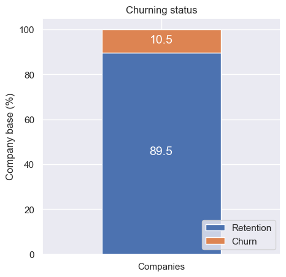

```python
plot_stacked_bars(churn_percentage.transpose(), "Churning status", (5, 5), legend_="lower right")
```

10.5% of the total customers have churned. (This sounds about right)

# Channel sales

```python
# Select the 'id', 'channel_sales', and 'churn' columns from the client_df DataFrame
channel = client_df[['id', 'channel_sales', 'churn']]

# Group the data by 'channel_sales' and 'churn', and count the number of 'id' values in each group
channel = channel.groupby([channel['channel_sales'], channel['churn']])['id'].count()

# Unstack the grouped data, making 'churn' values (0 and 1) into separate columns
channel = channel.unstack(level=1)

# Fill any missing (NaN) values with 0
channel = channel.fillna(0)

# Calculate the percentage of churn (1) for each 'channel_sales' category
channel_churn = (channel.div(channel.sum(axis=1), axis=0) * 100)

# Sort the resulting DataFrame by the percentage of churn (1) in descending order
channel_churn = channel_churn.sort_values(by=[1], ascending=False)
```

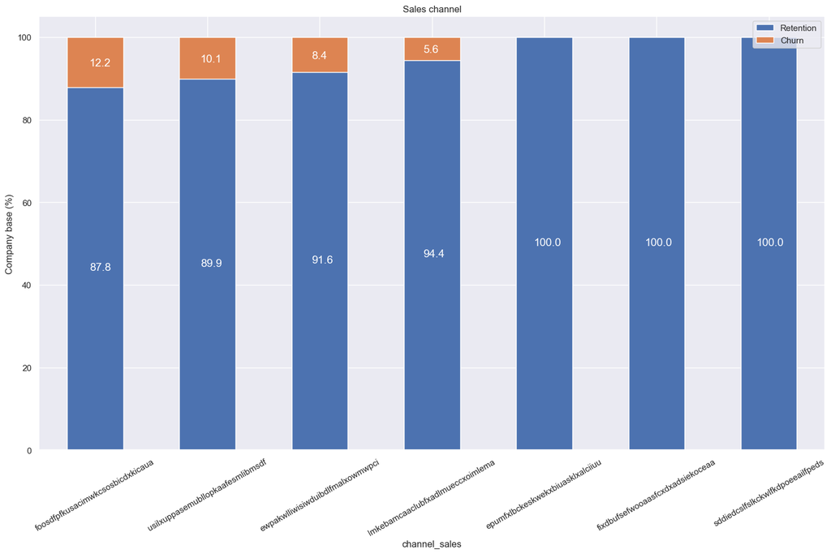

```python
plot_stacked_bars(channel_churn, 'Sales channel', rot_=30)
```

# Consumption

```python
consumption = client_df[['id', 'cons_12m', 'cons_gas_12m', 'cons_last_month', 'imp_cons', 'has_gas', 'churn']]
```

```python
def plot_distribution(dataframe, column, ax, bins_=50):
    """
    Plot variable distirbution in a stacked histogram of churned or retained company
    """
    # Create a temporal dataframe with the data to be plot
    temp = pd.DataFrame({"Retention": dataframe[dataframe["churn"]==0][column],
    "Churn":dataframe[dataframe["churn"]==1][column]})
    # Plot the histogram
    temp[["Retention","Churn"]].plot(kind='hist', bins=bins_, ax=ax, stacked=True)
    # X-axis label
    ax.set_xlabel(column)
    # Change the x-axis to plain style
    ax.ticklabel_format(style='plain', axis='x')
```

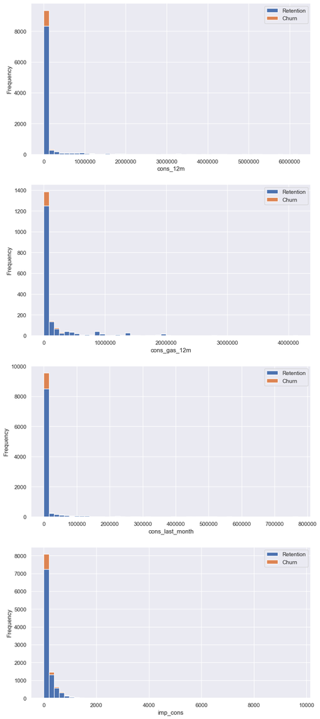

```python
fig, axs = plt.subplots(nrows=4, figsize=(10, 25))

plot_distribution(consumption, 'cons_12m', axs[0])
plot_distribution(consumption[consumption['has_gas'] == 't'], 'cons_gas_12m', axs[1])
plot_distribution(consumption, 'cons_last_month', axs[2])
plot_distribution(consumption, 'imp_cons', axs[3])
```

The consumption data exhibits a pronounced positive skewness, indicating that it is skewed towards higher values with an elongated right tail in its distribution. This elongation suggests the presence of outliers, which are values that significantly deviate from the majority of the data points. To gain deeper insights into these outliers, we can employ a standard visualization technique – the boxplot.

A boxplot offers a standardized representation of the data's distribution by highlighting key statistical measures:

- The minimum value
- The first quartile (Q1)
- The median
- The third quartile (Q3)
- The maximum value

This visualization not only helps us identify outliers but also provides information about the data's symmetry, the tightness of data clustering, and the extent of its skewness. It is a valuable tool for gaining a comprehensive understanding of the data's characteristics.

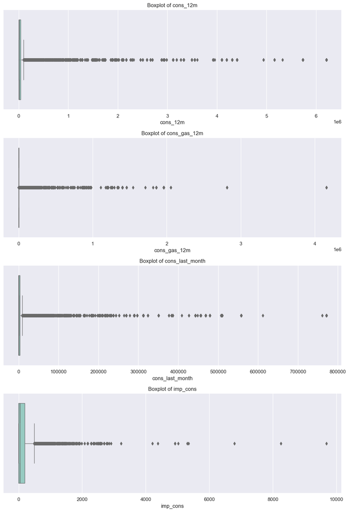

```python
import matplotlib.pyplot as plt
import seaborn as sns

# Specify the columns you want to create boxplots for
columns_to_plot = ["cons_12m", "cons_gas_12m", "cons_last_month", "imp_cons"]

# Create a figure with subplots
fig, axs = plt.subplots(nrows=len(columns_to_plot), figsize=(11, 4 * len(columns_to_plot)))

# Loop through columns and create boxplots with customizations
for i, column in enumerate(columns_to_plot):
    sns.boxplot(x=column, data=consumption, ax=axs[i], linewidth=1, notch=True, fliersize=5, palette="Set3")
    axs[i].set_title(f"Boxplot of {column}")
    axs[i].set_xlabel(column)

plt.tight_layout()  # Adjust subplot spacing
plt.show()
```

There are a lot of outliers

# Forecast

```python
forecast = client_df[
    ["id", "forecast_cons_12m"	,"forecast_cons_year"	,"forecast_discount_energy",	"forecast_meter_rent_12m"	,"forecast_price_energy_off_peak" ,	"forecast_price_energy_peak"	,"forecast_price_pow_off_peak"	,
     "churn"
    ]
]
```

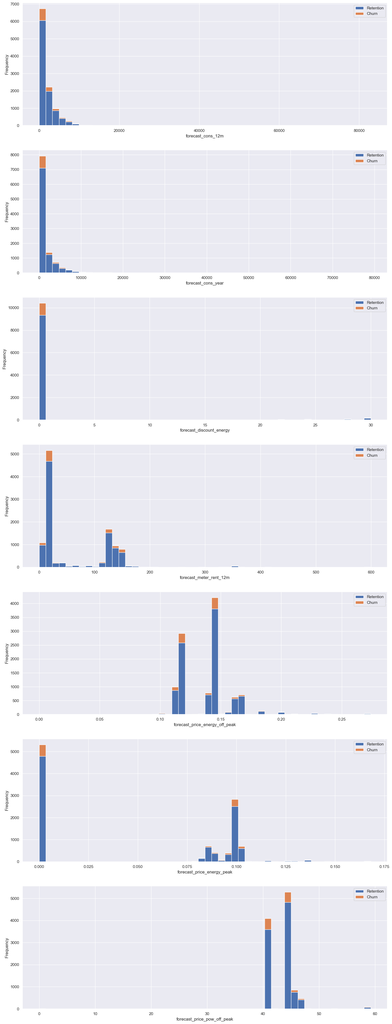

```python
fig, axs = plt.subplots(nrows=7, figsize=(18,50))

# Plot histogram
plot_distribution(client_df, "forecast_cons_12m", axs[0])
plot_distribution(client_df, "forecast_cons_year", axs[1])
plot_distribution(client_df, "forecast_discount_energy", axs[2])
plot_distribution(client_df, "forecast_meter_rent_12m", axs[3])
plot_distribution(client_df, "forecast_price_energy_off_peak", axs[4])
plot_distribution(client_df, "forecast_price_energy_peak", axs[5])
plot_distribution(client_df, "forecast_price_pow_off_peak", axs[6])
```

Similarly to the consumption plots, we can observe that a lot of the variables are highly positively skewed, creating a very long tail for the higher values

# Contract

```python
#contact type
contract_type = client_df[['id', 'has_gas', 'churn']]
contract = contract_type.groupby([contract_type['churn'], contract_type['has_gas']])['id'].count().unstack(level=0)
contract_percentage = (contract.div(contract.sum(axis=1), axis=0) * 100).sort_values(by=[1], ascending=False)
```

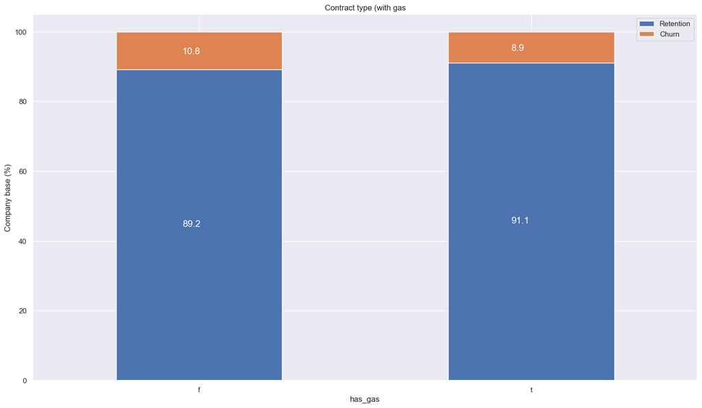

```python
plot_stacked_bars(contract_percentage, 'Contract type (with gas')
```

# Margins

```python
margin = client_df[['id', 'margin_gross_pow_ele', 'margin_net_pow_ele', 'net_margin']]
```

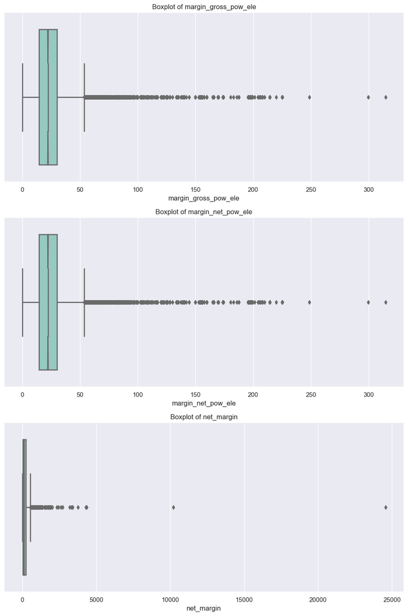

```python
def plot_boxplots(dataframe, columns_to_plot):
    # Create a figure with subplots
    fig, axs = plt.subplots(nrows=len(columns_to_plot), figsize=(10, 5 * len(columns_to_plot)))

    # Loop through columns and create boxplots with customizations
    for i, column in enumerate(columns_to_plot):
        sns.boxplot(x=column, data=dataframe, ax=axs[i], linewidth=2, notch=True, fliersize=5, palette="Set3")
        axs[i].set_title(f"Boxplot of {column}")
        axs[i].set_xlabel(column)

    plt.tight_layout()  # Adjust subplot spacing
    plt.show()

# Specify the columns you want to create boxplots for in the margin DataFrame
columns_to_plot = ["margin_gross_pow_ele", "margin_net_pow_ele", "net_margin"]

# Call the function to create boxplots
plot_boxplots(margin, columns_to_plot)
```

# Subscribed power

```python
power = client_df[['id', 'pow_max', 'churn']]
```

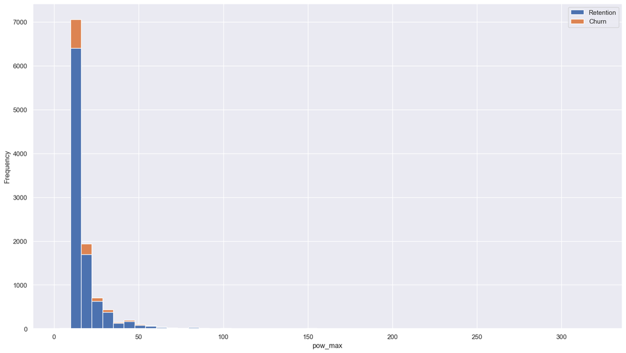

```python
fig, axs = plt.subplots(nrows=1, figsize=(18, 10))
plot_distribution(power, 'pow_max', axs)
```

# Other columns

```python
others = client_df[['id', 'nb_prod_act', 'num_years_antig', 'origin_up', 'churn']]
products = others.groupby([others["nb_prod_act"],others["churn"]])["id"].count().unstack(level=1)
products_percentage = (products.div(products.sum(axis=1), axis=0)*100).sort_values(by=[1], ascending=False)
```

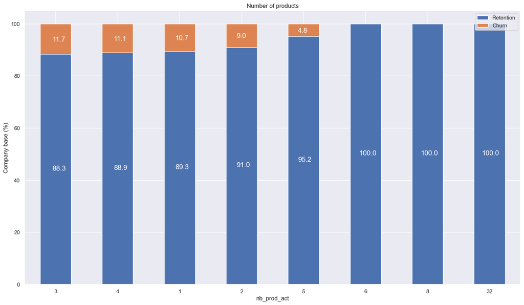

```python
plot_stacked_bars(products_percentage, "Number of products")
```

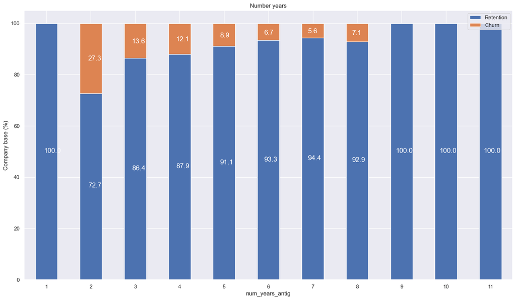

```python
years_antig = others.groupby([others["num_years_antig"],others["churn"]])["id"].count().unstack(level=1)
years_antig_percentage = (years_antig.div(years_antig.sum(axis=1), axis=0)*100)
plot_stacked_bars(years_antig_percentage, "Number years")
```

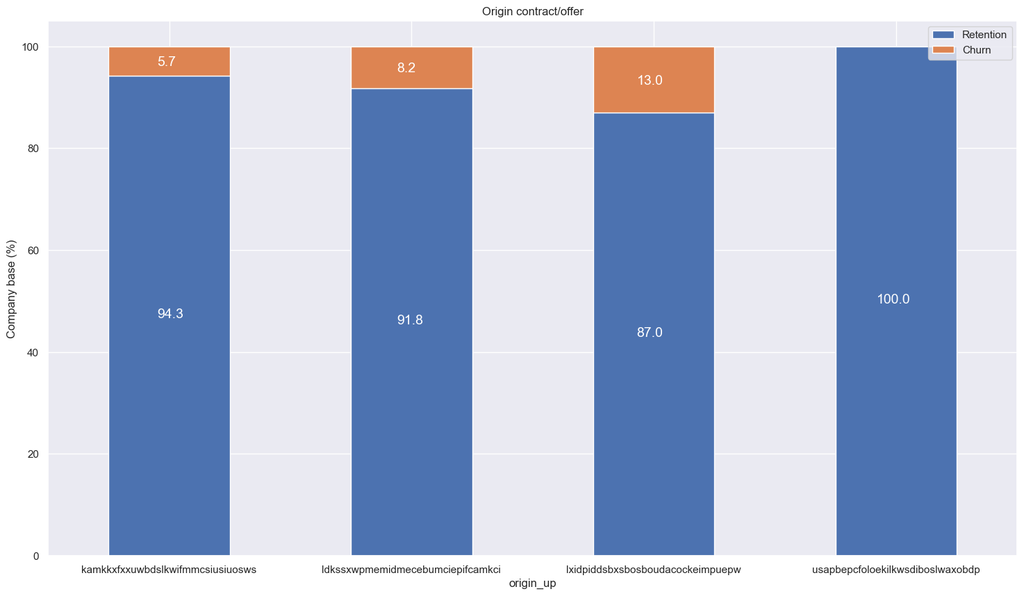

```python
origin = others.groupby([others["origin_up"],others["churn"]])["id"].count().unstack(level=1)
origin_percentage = (origin.div(origin.sum(axis=1), axis=0)*100)
plot_stacked_bars(origin_percentage, "Origin contract/offer")
```

# Hypothesis investigation

```python
# Transform date columns to datetime type
client_df["date_activ"] = pd.to_datetime(client_df["date_activ"], format='%Y-%m-%d')
client_df["date_end"] = pd.to_datetime(client_df["date_end"], format='%Y-%m-%d')
client_df["date_modif_prod"] = pd.to_datetime(client_df["date_modif_prod"], format='%Y-%m-%d')
client_df["date_renewal"] = pd.to_datetime(client_df["date_renewal"], format='%Y-%m-%d')
price_df['price_date'] = pd.to_datetime(price_df['price_date'], format='%Y-%m-%d')

# Create mean average data
mean_year = price_df.groupby(['id']).mean().reset_index()

mean_6m = price_df[price_df['price_date'] > '2015-06-01'].groupby(['id']).mean().reset_index()

mean_3m = price_df[price_df['price_date'] > '2015-10-01'].groupby(['id']).mean().reset_index()
```

```python
mean_year
```

|  | id | price_date | price_off_peak_var | price_peak_var | price_mid_peak_var | price_off_peak_fix | price_peak_fix | price_mid_peak_fix |
| --- | --- | --- | --- | --- | --- | --- | --- | --- |
| 0 | 0002203ffbb812588b632b9e628cc38d | 2015-06-16 12:00:00 | 0.124338 | 0.103794 | 0.073160 | 40.701732 | 24.421038 | 16.280694 |
| 1 | 0004351ebdd665e6ee664792efc4fd13 | 2015-06-16 12:00:00 | 0.146426 | 0.000000 | 0.000000 | 44.385450 | 0.000000 | 0.000000 |
| 2 | 0010bcc39e42b3c2131ed2ce55246e3c | 2015-06-16 12:00:00 | 0.181558 | 0.000000 | 0.000000 | 45.319710 | 0.000000 | 0.000000 |
| 3 | 0010ee3855fdea87602a5b7aba8e42de | 2015-06-16 12:00:00 | 0.118757 | 0.098292 | 0.069032 | 40.647427 | 24.388455 | 16.258971 |
| 4 | 00114d74e963e47177db89bc70108537 | 2015-06-16 12:00:00 | 0.147926 | 0.000000 | 0.000000 | 44.266930 | 0.000000 | 0.000000 |
| ... | ... | ... | ... | ... | ... | ... | ... | ... |
| 16091 | ffef185810e44254c3a4c6395e6b4d8a | 2015-06-16 12:00:00 | 0.138863 | 0.115125 | 0.080780 | 40.896427 | 24.637456 | 16.507972 |
| 16092 | fffac626da707b1b5ab11e8431a4d0a2 | 2015-06-16 12:00:00 | 0.147137 | 0.000000 | 0.000000 | 44.311375 | 0.000000 | 0.000000 |
| 16093 | fffc0cacd305dd51f316424bbb08d1bd | 2015-06-16 12:00:00 | 0.153879 | 0.129497 | 0.094842 | 41.160171 | 24.895768 | 16.763569 |
| 16094 | fffe4f5646aa39c7f97f95ae2679ce64 | 2015-06-16 12:00:00 | 0.123858 | 0.103499 | 0.073735 | 40.606699 | 24.364017 | 16.242678 |
| 16095 | ffff7fa066f1fb305ae285bb03bf325a | 2015-06-16 12:00:00 | 0.125360 | 0.104895 | 0.075635 | 40.647427 | 24.388455 | 16.258971 |

16096 rows × 8 columns

```python
mean_6m
```

|  | id | price_date | price_off_peak_var | price_peak_var | price_mid_peak_var | price_off_peak_fix | price_peak_fix | price_mid_peak_fix |
| --- | --- | --- | --- | --- | --- | --- | --- | --- |
| 0 | 0002203ffbb812588b632b9e628cc38d | 2015-09-15 20:00:00 | 0.121266 | 0.102368 | 0.073728 | 40.728885 | 24.437330 | 16.291555 |
| 1 | 0004351ebdd665e6ee664792efc4fd13 | 2015-09-15 20:00:00 | 0.144687 | 0.000000 | 0.000000 | 44.444710 | 0.000000 | 0.000000 |
| 2 | 0010bcc39e42b3c2131ed2ce55246e3c | 2015-09-15 20:00:00 | 0.202024 | 0.000000 | 0.000000 | 45.944710 | 0.000000 | 0.000000 |
| 3 | 0010ee3855fdea87602a5b7aba8e42de | 2015-09-15 20:00:00 | 0.114428 | 0.096080 | 0.069418 | 40.728885 | 24.437330 | 16.291555 |
| 4 | 00114d74e963e47177db89bc70108537 | 2015-09-15 20:00:00 | 0.146184 | 0.000000 | 0.000000 | 44.266930 | 0.000000 | 0.000000 |
| ... | ... | ... | ... | ... | ... | ... | ... | ... |
| 16091 | ffef185810e44254c3a4c6395e6b4d8a | 2015-09-15 20:00:00 | 0.113848 | 0.095499 | 0.068838 | 40.728885 | 24.437330 | 16.291555 |
| 16092 | fffac626da707b1b5ab11e8431a4d0a2 | 2015-09-15 20:00:00 | 0.145449 | 0.000000 | 0.000000 | 44.355820 | 0.000000 | 0.000000 |
| 16093 | fffc0cacd305dd51f316424bbb08d1bd | 2015-09-15 20:00:00 | 0.152759 | 0.127566 | 0.091403 | 41.228885 | 24.937330 | 16.791555 |
| 16094 | fffe4f5646aa39c7f97f95ae2679ce64 | 2015-09-15 20:00:00 | 0.120150 | 0.101570 | 0.073983 | 40.647429 | 24.388454 | 16.258969 |
| 16095 | ffff7fa066f1fb305ae285bb03bf325a | 2015-09-15 20:00:00 | 0.121276 | 0.102927 | 0.076266 | 40.728885 | 24.437330 | 16.291555 |

16096 rows × 8 columns

```python
mean_year.to_csv('C:/Users/Tasnim/Desktop/dataUsed2/meanYear.csv', index=False)
```

```python
# Rename columns in the 'mean_year' DataFrame
mean_year.rename(
    columns={
        "price_off_peak_var": "mean_year_price_p1_var",
        "price_peak_var": "mean_year_price_p2_var",
        "price_mid_peak_var": "mean_year_price_p3_var",
        "price_off_peak_fix": "mean_year_price_p1_fix",
        "price_peak_fix": "mean_year_price_p2_fix",
        "price_mid_peak_fix": "mean_year_price_p3_fix"
    },
    inplace=True  # Apply changes to the DataFrame in place
)
```

```python
mean_year
```

|  | id | price_date | mean_year_price_p1_var | mean_year_price_p2_var | mean_year_price_p3_var | mean_year_price_p1_fix | mean_year_price_p2_fix | mean_year_price_p3_fix |
| --- | --- | --- | --- | --- | --- | --- | --- | --- |
| 0 | 0002203ffbb812588b632b9e628cc38d | 2015-06-16 12:00:00 | 0.124338 | 0.103794 | 0.073160 | 40.701732 | 24.421038 | 16.280694 |
| 1 | 0004351ebdd665e6ee664792efc4fd13 | 2015-06-16 12:00:00 | 0.146426 | 0.000000 | 0.000000 | 44.385450 | 0.000000 | 0.000000 |
| 2 | 0010bcc39e42b3c2131ed2ce55246e3c | 2015-06-16 12:00:00 | 0.181558 | 0.000000 | 0.000000 | 45.319710 | 0.000000 | 0.000000 |
| 3 | 0010ee3855fdea87602a5b7aba8e42de | 2015-06-16 12:00:00 | 0.118757 | 0.098292 | 0.069032 | 40.647427 | 24.388455 | 16.258971 |
| 4 | 00114d74e963e47177db89bc70108537 | 2015-06-16 12:00:00 | 0.147926 | 0.000000 | 0.000000 | 44.266930 | 0.000000 | 0.000000 |
| ... | ... | ... | ... | ... | ... | ... | ... | ... |
| 16091 | ffef185810e44254c3a4c6395e6b4d8a | 2015-06-16 12:00:00 | 0.138863 | 0.115125 | 0.080780 | 40.896427 | 24.637456 | 16.507972 |
| 16092 | fffac626da707b1b5ab11e8431a4d0a2 | 2015-06-16 12:00:00 | 0.147137 | 0.000000 | 0.000000 | 44.311375 | 0.000000 | 0.000000 |
| 16093 | fffc0cacd305dd51f316424bbb08d1bd | 2015-06-16 12:00:00 | 0.153879 | 0.129497 | 0.094842 | 41.160171 | 24.895768 | 16.763569 |
| 16094 | fffe4f5646aa39c7f97f95ae2679ce64 | 2015-06-16 12:00:00 | 0.123858 | 0.103499 | 0.073735 | 40.606699 | 24.364017 | 16.242678 |
| 16095 | ffff7fa066f1fb305ae285bb03bf325a | 2015-06-16 12:00:00 | 0.125360 | 0.104895 | 0.075635 | 40.647427 | 24.388455 | 16.258971 |

16096 rows × 8 columns

```python
mean_year["mean_year_price_p1"] = mean_year["mean_year_price_p1_var"] + mean_year["mean_year_price_p1_fix"]
mean_year["mean_year_price_p2"] = mean_year["mean_year_price_p2_var"] + mean_year["mean_year_price_p2_fix"]
mean_year["mean_year_price_p3"] = mean_year["mean_year_price_p3_var"] + mean_year["mean_year_price_p3_fix"]
```

```python
mean_year.head(4)
```

|  | id | price_date | mean_year_price_p1_var | mean_year_price_p2_var | mean_year_price_p3_var | mean_year_price_p1_fix | mean_year_price_p2_fix | mean_year_price_p3_fix | mean_year_price_p1 | mean_year_price_p2 | mean_year_price_p3 |
| --- | --- | --- | --- | --- | --- | --- | --- | --- | --- | --- | --- |
| 0 | 0002203ffbb812588b632b9e628cc38d | 2015-06-16 12:00:00 | 0.124338 | 0.103794 | 0.073160 | 40.701732 | 24.421038 | 16.280694 | 40.826071 | 24.524832 | 16.353854 |
| 1 | 0004351ebdd665e6ee664792efc4fd13 | 2015-06-16 12:00:00 | 0.146426 | 0.000000 | 0.000000 | 44.385450 | 0.000000 | 0.000000 | 44.531877 | 0.000000 | 0.000000 |
| 2 | 0010bcc39e42b3c2131ed2ce55246e3c | 2015-06-16 12:00:00 | 0.181558 | 0.000000 | 0.000000 | 45.319710 | 0.000000 | 0.000000 | 45.501268 | 0.000000 | 0.000000 |
| 3 | 0010ee3855fdea87602a5b7aba8e42de | 2015-06-16 12:00:00 | 0.118757 | 0.098292 | 0.069032 | 40.647427 | 24.388455 | 16.258971 | 40.766185 | 24.486748 | 16.328003 |

```python
# Rename columns in the 'mean_6m' DataFrame
mean_6m.rename(
    columns={
        "price_off_peak_var": "mean_6m_price_p1_var",
        "price_peak_var": "mean_6m_price_p2_var",
        "price_mid_peak_var": "mean_6m_price_p3_var",
        "price_off_peak_fix": "mean_6m_price_p1_fix",
        "price_peak_fix": "mean_6m_price_p2_fix",
        "price_mid_peak_fix": "mean_6m_price_p3_fix"
    },
    inplace=True  # Apply changes to the DataFrame in place
)
```

```python
# Create new columns in 'mean_6m' DataFrame
mean_6m["mean_6m_price_p1"] = mean_6m["mean_6m_price_p1_var"] + mean_6m["mean_6m_price_p1_fix"]
mean_6m["mean_6m_price_p2"] = mean_6m["mean_6m_price_p2_var"] + mean_6m["mean_6m_price_p2_fix"]
mean_6m["mean_6m_price_p3"] = mean_6m["mean_6m_price_p3_var"] + mean_6m["mean_6m_price_p3_fix"]
```

```python
# Rename columns in the 'mean_3m' DataFrame
mean_3m.rename(
    columns={
        "price_off_peak_var": "mean_3m_price_p1_var",
        "price_peak_var": "mean_3m_price_p2_var",
        "price_mid_peak_var": "mean_3m_price_p3_var",
        "price_off_peak_fix": "mean_3m_price_p1_fix",
        "price_peak_fix": "mean_3m_price_p2_fix",
        "price_mid_peak_fix": "mean_3m_price_p3_fix"
    },
    inplace=True  # Apply changes to the DataFrame in place
)
```

```python
# Create new columns in 'mean_3m' DataFrame
mean_3m["mean_3m_price_p1"] = mean_3m["mean_3m_price_p1_var"] + mean_3m["mean_3m_price_p1_fix"]
mean_3m["mean_3m_price_p2"] = mean_3m["mean_3m_price_p2_var"] + mean_3m["mean_3m_price_p2_fix"]
mean_3m["mean_3m_price_p3"] = mean_3m["mean_3m_price_p3_var"] + mean_3m["mean_3m_price_p3_fix"]
```

```python
mean_3m.head(3)
```

|  | id | price_date | mean_3m_price_p1_var | mean_3m_price_p2_var | mean_3m_price_p3_var | mean_3m_price_p1_fix | mean_3m_price_p2_fix | mean_3m_price_p3_fix | mean_3m_price_p1 | mean_3m_price_p2 | mean_3m_price_p3 |
| --- | --- | --- | --- | --- | --- | --- | --- | --- | --- | --- | --- |
| 0 | 0002203ffbb812588b632b9e628cc38d | 2015-11-16 | 0.119906 | 0.101673 | 0.073719 | 40.728885 | 24.43733 | 16.291555 | 40.848791 | 24.539003 | 16.365274 |
| 1 | 0004351ebdd665e6ee664792efc4fd13 | 2015-11-16 | 0.143943 | 0.000000 | 0.000000 | 44.444710 | 0.00000 | 0.000000 | 44.588653 | 0.000000 | 0.000000 |
| 2 | 0010bcc39e42b3c2131ed2ce55246e3c | 2015-11-16 | 0.201280 | 0.000000 | 0.000000 | 45.944710 | 0.00000 | 0.000000 | 46.145990 | 0.000000 | 0.000000 |

```python
mean_6m.head(3)
```

|  | id | price_date | mean_6m_price_p1_var | mean_6m_price_p2_var | mean_6m_price_p3_var | mean_6m_price_p1_fix | mean_6m_price_p2_fix | mean_6m_price_p3_fix | mean_6m_price_p1 | mean_6m_price_p2 | mean_6m_price_p3 |
| --- | --- | --- | --- | --- | --- | --- | --- | --- | --- | --- | --- |
| 0 | 0002203ffbb812588b632b9e628cc38d | 2015-09-15 20:00:00 | 0.121266 | 0.102368 | 0.073728 | 40.728885 | 24.43733 | 16.291555 | 40.850151 | 24.539698 | 16.365283 |
| 1 | 0004351ebdd665e6ee664792efc4fd13 | 2015-09-15 20:00:00 | 0.144687 | 0.000000 | 0.000000 | 44.444710 | 0.00000 | 0.000000 | 44.589397 | 0.000000 | 0.000000 |
| 2 | 0010bcc39e42b3c2131ed2ce55246e3c | 2015-09-15 20:00:00 | 0.202024 | 0.000000 | 0.000000 | 45.944710 | 0.00000 | 0.000000 | 46.146734 | 0.000000 | 0.000000 |

```python
price_features = pd.merge(mean_year, mean_6m, on='id')
```

```python
price_features = pd.merge(price_features, mean_3m, on='id')
```

```python
price_features.head(3)
```

|  | id | price_date_x | mean_year_price_p1_var | mean_year_price_p2_var | mean_year_price_p3_var | mean_year_price_p1_fix | mean_year_price_p2_fix | mean_year_price_p3_fix | mean_year_price_p1 | mean_year_price_p2 | ... | price_date | mean_3m_price_p1_var | mean_3m_price_p2_var | mean_3m_price_p3_var | mean_3m_price_p1_fix | mean_3m_price_p2_fix | mean_3m_price_p3_fix | mean_3m_price_p1 | mean_3m_price_p2 | mean_3m_price_p3 |
| --- | --- | --- | --- | --- | --- | --- | --- | --- | --- | --- | --- | --- | --- | --- | --- | --- | --- | --- | --- | --- | --- |
| 0 | 0002203ffbb812588b632b9e628cc38d | 2015-06-16 12:00:00 | 0.124338 | 0.103794 | 0.07316 | 40.701732 | 24.421038 | 16.280694 | 40.826071 | 24.524832 | ... | 2015-11-16 | 0.119906 | 0.101673 | 0.073719 | 40.728885 | 24.43733 | 16.291555 | 40.848791 | 24.539003 | 16.365274 |
| 1 | 0004351ebdd665e6ee664792efc4fd13 | 2015-06-16 12:00:00 | 0.146426 | 0.000000 | 0.00000 | 44.385450 | 0.000000 | 0.000000 | 44.531877 | 0.000000 | ... | 2015-11-16 | 0.143943 | 0.000000 | 0.000000 | 44.444710 | 0.00000 | 0.000000 | 44.588653 | 0.000000 | 0.000000 |
| 2 | 0010bcc39e42b3c2131ed2ce55246e3c | 2015-06-16 12:00:00 | 0.181558 | 0.000000 | 0.00000 | 45.319710 | 0.000000 | 0.000000 | 45.501268 | 0.000000 | ... | 2015-11-16 | 0.201280 | 0.000000 | 0.000000 | 45.944710 | 0.00000 | 0.000000 | 46.145990 | 0.000000 | 0.000000 |

3 rows × 31 columns

```python
price_features.info()
```

```
<class 'pandas.core.frame.DataFrame'>
RangeIndex: 16095 entries, 0 to 16094
Data columns (total 31 columns):
 #   Column                  Non-Null Count  Dtype
---  ------                  --------------  -----
 0   id                      16095 non-null  object
 1   price_date_x            16095 non-null  datetime64[ns]
 2   mean_year_price_p1_var  16095 non-null  float64
 3   mean_year_price_p2_var  16095 non-null  float64
 4   mean_year_price_p3_var  16095 non-null  float64
 5   mean_year_price_p1_fix  16095 non-null  float64
 6   mean_year_price_p2_fix  16095 non-null  float64
 7   mean_year_price_p3_fix  16095 non-null  float64
 8   mean_year_price_p1      16095 non-null  float64
 9   mean_year_price_p2      16095 non-null  float64
```

[output cut: 23 more lines]

```python
columns_to_drop = ['price_date', 'price_date_y', 'price_date_x']
price_features = price_features.drop(columns=columns_to_drop)
```

```python
price_features.head()
```

|  | id | mean_year_price_p1_var | mean_year_price_p2_var | mean_year_price_p3_var | mean_year_price_p1_fix | mean_year_price_p2_fix | mean_year_price_p3_fix | mean_year_price_p1 | mean_year_price_p2 | mean_year_price_p3 | ... | mean_6m_price_p3 | mean_3m_price_p1_var | mean_3m_price_p2_var | mean_3m_price_p3_var | mean_3m_price_p1_fix | mean_3m_price_p2_fix | mean_3m_price_p3_fix | mean_3m_price_p1 | mean_3m_price_p2 | mean_3m_price_p3 |
| --- | --- | --- | --- | --- | --- | --- | --- | --- | --- | --- | --- | --- | --- | --- | --- | --- | --- | --- | --- | --- | --- |
| 0 | 0002203ffbb812588b632b9e628cc38d | 0.124338 | 0.103794 | 0.073160 | 40.701732 | 24.421038 | 16.280694 | 40.826071 | 24.524832 | 16.353854 | ... | 16.365283 | 0.119906 | 0.101673 | 0.073719 | 40.728885 | 24.43733 | 16.291555 | 40.848791 | 24.539003 | 16.365274 |
| 1 | 0004351ebdd665e6ee664792efc4fd13 | 0.146426 | 0.000000 | 0.000000 | 44.385450 | 0.000000 | 0.000000 | 44.531877 | 0.000000 | 0.000000 | ... | 0.000000 | 0.143943 | 0.000000 | 0.000000 | 44.444710 | 0.00000 | 0.000000 | 44.588653 | 0.000000 | 0.000000 |
| 2 | 0010bcc39e42b3c2131ed2ce55246e3c | 0.181558 | 0.000000 | 0.000000 | 45.319710 | 0.000000 | 0.000000 | 45.501268 | 0.000000 | 0.000000 | ... | 0.000000 | 0.201280 | 0.000000 | 0.000000 | 45.944710 | 0.00000 | 0.000000 | 46.145990 | 0.000000 | 0.000000 |
| 3 | 0010ee3855fdea87602a5b7aba8e42de | 0.118757 | 0.098292 | 0.069032 | 40.647427 | 24.388455 | 16.258971 | 40.766185 | 24.486748 | 16.328003 | ... | 16.360973 | 0.113068 | 0.095385 | 0.069409 | 40.728885 | 24.43733 | 16.291555 | 40.841953 | 24.532715 | 16.360964 |
| 4 | 00114d74e963e47177db89bc70108537 | 0.147926 | 0.000000 | 0.000000 | 44.266930 | 0.000000 | 0.000000 | 44.414856 | 0.000000 | 0.000000 | ... | 0.000000 | 0.145440 | 0.000000 | 0.000000 | 44.266930 | 0.00000 | 0.000000 | 44.412370 | 0.000000 | 0.000000 |

5 rows × 28 columns

```python
price_analysis = pd.merge(price_features, client_df[['id', 'churn']], on='id')
price_analysis.head()
```

|  | id | mean_year_price_p1_var | mean_year_price_p2_var | mean_year_price_p3_var | mean_year_price_p1_fix | mean_year_price_p2_fix | mean_year_price_p3_fix | mean_year_price_p1 | mean_year_price_p2 | mean_year_price_p3 | ... | mean_3m_price_p1_var | mean_3m_price_p2_var | mean_3m_price_p3_var | mean_3m_price_p1_fix | mean_3m_price_p2_fix | mean_3m_price_p3_fix | mean_3m_price_p1 | mean_3m_price_p2 | mean_3m_price_p3 | churn |
| --- | --- | --- | --- | --- | --- | --- | --- | --- | --- | --- | --- | --- | --- | --- | --- | --- | --- | --- | --- | --- | --- |
| 0 | 0002203ffbb812588b632b9e628cc38d | 0.124338 | 0.103794 | 0.073160 | 40.701732 | 24.421038 | 16.280694 | 40.826071 | 24.524832 | 16.353854 | ... | 0.119906 | 0.101673 | 0.073719 | 40.728885 | 24.43733 | 16.291555 | 40.848791 | 24.539003 | 16.365274 | 0 |
| 1 | 0010bcc39e42b3c2131ed2ce55246e3c | 0.181558 | 0.000000 | 0.000000 | 45.319710 | 0.000000 | 0.000000 | 45.501268 | 0.000000 | 0.000000 | ... | 0.201280 | 0.000000 | 0.000000 | 45.944710 | 0.00000 | 0.000000 | 46.145990 | 0.000000 | 0.000000 | 0 |
| 2 | 00114d74e963e47177db89bc70108537 | 0.147926 | 0.000000 | 0.000000 | 44.266930 | 0.000000 | 0.000000 | 44.414856 | 0.000000 | 0.000000 | ... | 0.145440 | 0.000000 | 0.000000 | 44.266930 | 0.00000 | 0.000000 | 44.412370 | 0.000000 | 0.000000 | 0 |
| 3 | 0013f326a839a2f6ad87a1859952d227 | 0.126076 | 0.105542 | 0.074921 | 40.728885 | 24.437330 | 16.291555 | 40.854961 | 24.542872 | 16.366476 | ... | 0.121647 | 0.103413 | 0.075460 | 40.728885 | 24.43733 | 16.291555 | 40.850532 | 24.540743 | 16.367015 | 0 |
| 4 | 00184e957277eeef733a7b563fdabd06 | 0.147637 | 0.000000 | 0.000000 | 44.266930 | 0.000000 | 0.000000 | 44.414568 | 0.000000 | 0.000000 | ... | 0.145093 | 0.000000 | 0.000000 | 44.266930 | 0.00000 | 0.000000 | 44.412023 | 0.000000 | 0.000000 | 0 |

5 rows × 29 columns

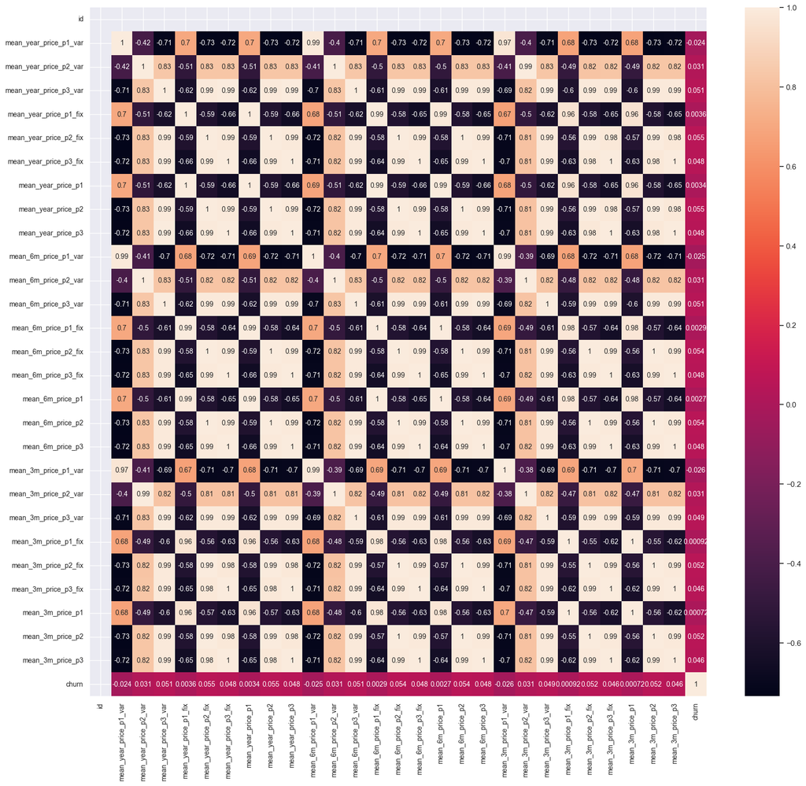

```python
price_analysis = price_analysis.apply(pd.to_numeric, errors='coerce')

corr = price_analysis.corr()
# Plot correlation
plt.figure(figsize=(20,18))
sns.heatmap(corr, xticklabels=corr.columns.values, yticklabels=corr.columns.values, annot = True, annot_kws={'size':10})
# Axis ticks size
plt.xticks(fontsize=10)
plt.yticks(fontsize=10)
plt.show()
```

From the correlation plot, it shows a higher magnitude of correlation between other price sensitivity variables, however overall the correlation with churn is very low. This indicates that there is a weak linear relationship between price sensitity and churn. This suggests that for price sensivity to be a major driver for predicting churn, we may need to engineer the feature differently.

```python
merged_data = pd.merge(client_df.drop(columns=['churn']), price_analysis, on='id')
```

```python
merged_data.head()
```

|  | id | channel_sales | cons_12m | cons_gas_12m | cons_last_month | date_activ | date_end | date_modif_prod | date_renewal | forecast_cons_12m | ... | mean_3m_price_p1_var | mean_3m_price_p2_var | mean_3m_price_p3_var | mean_3m_price_p1_fix | mean_3m_price_p2_fix | mean_3m_price_p3_fix | mean_3m_price_p1 | mean_3m_price_p2 | mean_3m_price_p3 | churn |
| --- | --- | --- | --- | --- | --- | --- | --- | --- | --- | --- | --- | --- | --- | --- | --- | --- | --- | --- | --- | --- | --- |
| 0 | 24011ae4ebbe3035111d65fa7c15bc57 | foosdfpfkusacimwkcsosbicdxkicaua | 0 | 54946 | 0 | 2013-06-15 | 2016-06-15 | 2015-11-01 | 2015-06-23 | 0.00 | ... | 0.131756 | 0.092638 | 0.036909 | 42.497907 | 12.218665 | 8.145777 | 42.629663 | 12.311304 | 8.182687 | 1 |
| 1 | 764c75f661154dac3a6c254cd082ea7d | foosdfpfkusacimwkcsosbicdxkicaua | 544 | 0 | 0 | 2010-04-16 | 2016-04-16 | 2010-04-16 | 2015-04-17 | 47.96 | ... | 0.167798 | 0.088409 | 0.000000 | 44.444710 | 0.000000 | 0.000000 | 44.612508 | 0.088409 | 0.000000 | 0 |
| 2 | bba03439a292a1e166f80264c16191cb | lmkebamcaaclubfxadlmueccxoimlema | 1584 | 0 | 0 | 2010-03-30 | 2016-03-30 | 2010-03-30 | 2015-03-31 | 240.04 | ... | 0.148586 | 0.000000 | 0.000000 | 44.444710 | 0.000000 | 0.000000 | 44.593296 | 0.000000 | 0.000000 | 0 |
| 3 | 1aa498825382410b098937d65c4ec26d | usilxuppasemubllopkaafesmlibmsdf | 8302 | 0 | 1998 | 2011-12-09 | 2016-12-09 | 2015-11-01 | 2015-12-10 | 796.94 | ... | 0.163659 | 0.084587 | 0.000000 | 44.266930 | 0.000000 | 0.000000 | 44.430589 | 0.084587 | 0.000000 | 1 |
| 4 | 7ab4bf4878d8f7661dfc20e9b8e18011 | foosdfpfkusacimwkcsosbicdxkicaua | 45097 | 0 | 0 | 2011-12-02 | 2016-12-02 | 2011-12-02 | 2015-12-03 | 8069.28 | ... | 0.163361 | 0.084305 | 0.000000 | 44.266930 | 0.000000 | 0.000000 | 44.430291 | 0.084305 | 0.000000 | 1 |

5 rows × 53 columns

```python
merged_data.to_csv('C:/Users/Tasnim/Desktop/dataUsed2/data_after_eda.csv')
```